# Insurance Price - EDA

The aim of this work is to provide a series of considerations on the given population by going to analyses the attributes and the relatioship between them. The data used is Medical Costs Datasets (available on github from here: https://github.com/stedy/Machine-Learning-with-R-datasets/blob/master/insurance.csv) and contains individual medical costs billed by health insurance.

The population is characterised by the following features:

- AGE: age of primary beneficiary
- SEX: insurance contractor gender
- BMI: body mass index, providing an understanding of body using the ratio of height to weight
- CHILDREN: number of children covered by health insurance
- SMOKER: if the individual smoks or not
- REGION: the beneficiary's residential area in the US

The target of our analisys is:

- CHARGES: Indivudual medical costs billed by health insurance

```python
import warnings
warnings.filterwarnings('ignore')
import pandas as pd
import numpy as np
import matplotlib.pyplot as plt
import seaborn as sn
```

```python
url = 'https://raw.githubusercontent.com/Emanuele-Cali/MedicalCosts/main/insurance.csv'
df = pd.read_csv(url)
```

```python
df.shape
```

```
(1338, 7)
```

```python
df.isnull().sum()
```

```
age         0
sex         0
bmi         0
children    0
smoker      0
region      0
charges     0
dtype: int64
```

```python
df.info()
```

```
<class 'pandas.core.frame.DataFrame'>
RangeIndex: 1338 entries, 0 to 1337
Data columns (total 7 columns):
 #   Column    Non-Null Count  Dtype
---  ------    --------------  -----
 0   age       1338 non-null   int64
 1   sex       1338 non-null   object
 2   bmi       1338 non-null   float64
 3   children  1338 non-null   int64
 4   smoker    1338 non-null   object
 5   region    1338 non-null   object
 6   charges   1338 non-null   float64
dtypes: float64(2), int64(2), object(3)
memory usage: 73.3+ KB
```

```python
df.describe()
```

|  | age | bmi | children | charges |
| --- | --- | --- | --- | --- |
| count | 1338.000000 | 1338.000000 | 1338.000000 | 1338.000000 |
| mean | 39.207025 | 30.663397 | 1.094918 | 13270.422265 |
| std | 14.049960 | 6.098187 | 1.205493 | 12110.011237 |
| min | 18.000000 | 15.960000 | 0.000000 | 1121.873900 |
| 25% | 27.000000 | 26.296250 | 0.000000 | 4740.287150 |
| 50% | 39.000000 | 30.400000 | 1.000000 | 9382.033000 |
| 75% | 51.000000 | 34.693750 | 2.000000 | 16639.912515 |
| max | 64.000000 | 53.130000 | 5.000000 | 63770.428010 |

There are no missing values and for this reason no data cleanining is needed.

We create a new categorical data using the bmi value. In particular we assign every benefiary to bmi_class according with the cdc guidelines to make some more analysis (https://www.cdc.gov/healthyweight/assessing/bmi/adult_bmi/english_bmi_calculator/bmi_calculator.html)

The new column will be:

- BMI_CLASSIFICATION: classification in Underweight, Healthy, Overweight, Obese

```python
df.loc[df.bmi<18.5, 'bmi_classification'] = 'Underweight'
df.loc[(df.bmi>= 18.5) & (df.bmi<=24.9), 'bmi_classification'] = 'Healthy'
df.loc[(df.bmi>24.9) & (df.bmi <=29.9), 'bmi_classification'] = 'Overweight'
df.loc[df.bmi>29.9, 'bmi_classification'] = 'Obese'
```

```python
df.head(3)
```

|  | age | sex | bmi | children | smoker | region | charges | bmi_classification |
| --- | --- | --- | --- | --- | --- | --- | --- | --- |
| 0 | 19 | female | 27.90 | 0 | yes | southwest | 16884.9240 | Overweight |
| 1 | 18 | male | 33.77 | 1 | no | southeast | 1725.5523 | Obese |
| 2 | 28 | male | 33.00 | 3 | no | southeast | 4449.4620 | Obese |

#### Usufull table

```python
male = df['sex'] == 'male'
ages = df.sort_values('age').age.unique()
smoker = df['smoker']=='yes'
regions = df['region'].unique()
```

## Explorotary Data Analisys

In this part of the survey we will use a lot of plots to understand the relationship between the variables. We will proceding taking a variable and than looking for relationship between this variable and the other.

### Feature : Age

#### Age frequencies

We start to see the age frequences for male e female, the age distribution and the proportion between male and female

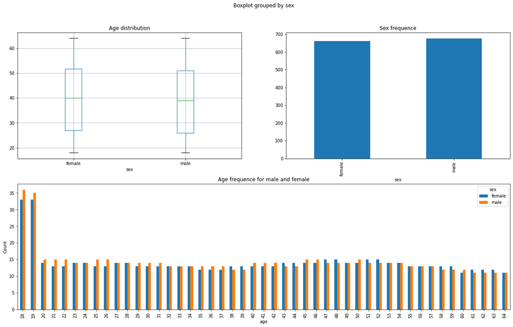

```python
sex_age = pd.crosstab(df.age, df.sex)

fig, (ax1, ax2) = plt.subplots(2, 1, figsize=(20,12))

ax1 = plt.subplot(212)
sex_age.plot(kind = 'bar', ax=ax1)
ax1.set_ylabel('Count')
ax1.set_title('Age frequence for male and female')

ax2 = plt.subplot(222)
ax2.margins()
df.groupby('sex').age.count().plot(kind='bar', ax=ax2)

ax2.set_title('Sex frequence')
ax3 = plt.subplot(221)
ax3.margins()
df.boxplot(by = 'sex', column='age', ax=ax3)
ax3.set_title('Age distribution')

plt.show()
```

We can see from this plots that we have a peak on 18 and 19 years where we see ~67 insurances and than the frquence will drop on ~30 insurances. The sex distribution along the years is comparable between male and female. We have a comparable proportion between male and female, we have 676 male and 662 female. From the boxplot we see that males are a little jounger than the females.

#### Age frequencies on regions

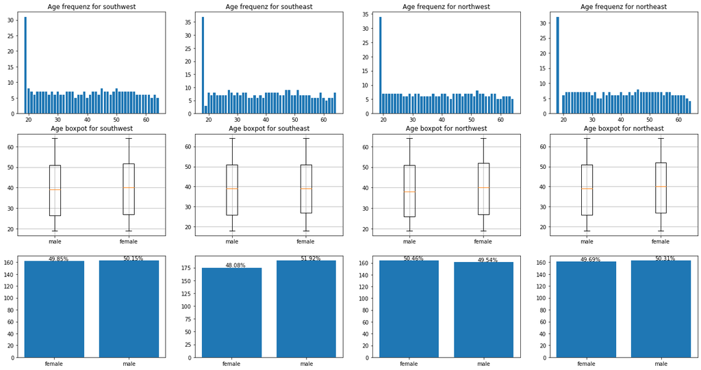

```python
fig, ax=plt.subplots(3,4, figsize=(23,12))

l = 0
for i in regions:
    df_region_i = df[df['region'] == i]
    ax[0,l].bar(df_region_i.age.value_counts().index, df_region_i.age.value_counts(), label=i)
    ax[0,l].set_title('Age frequenz for '+ i)

    ax[1,l].boxplot((df_region_i[male].age, df_region_i[~male].age))
    ax[1,l].set_xticklabels(['male','female'], rotation=0)
    ax[1,l].set_title('Age boxpot for '+ i)
    ax[1,l].grid()

    rap = ax[2,l].bar(df_region_i.groupby('sex').age.count().index, df_region_i.groupby('sex').age.count())

    for i in rap:
        tot = df_region_i.age.count()
        x,y = i.get_xy()
        al = i.get_height()
        la = i.get_width()
        ax[2,l].annotate(str(round(i.get_height()/tot*100,2))+'%', (x+la/2.5,y+al*1.007))

    l += 1

plt.show()
```

#### Age and bmi classification

Now we analyze the bmi classification along the years

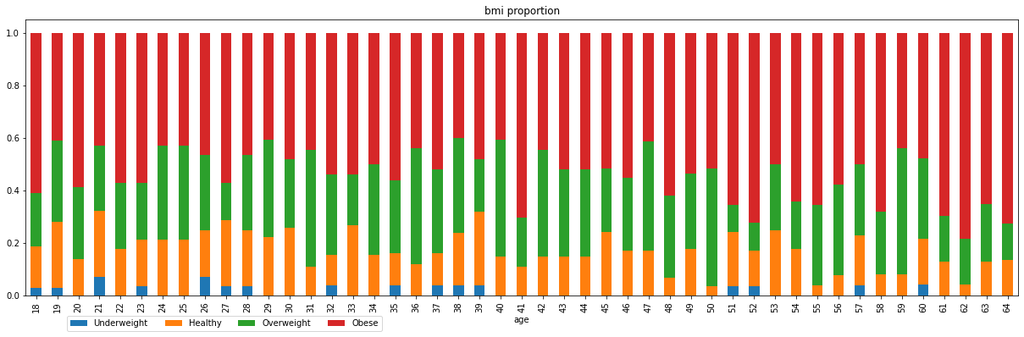

```python
tab = pd.crosstab(df.age, df.bmi_classification, normalize='index')

f, a = plt.subplots(figsize = (21,6))

fig = tab.plot.bar(y = ['Underweight','Healthy','Overweight','Obese'], stacked=True, ax =a)
plt.title('bmi proportion')
plt.legend(bbox_to_anchor=[0.2, - 0.1], loc= 'center',ncol = 4)
plt.show()
```

#### Age and smoker

Now we analyze the relationship between the smoker attribut with age and sex attributes. We will see the frequence of smokers along the years and the proportion of smoker on sex attribute.

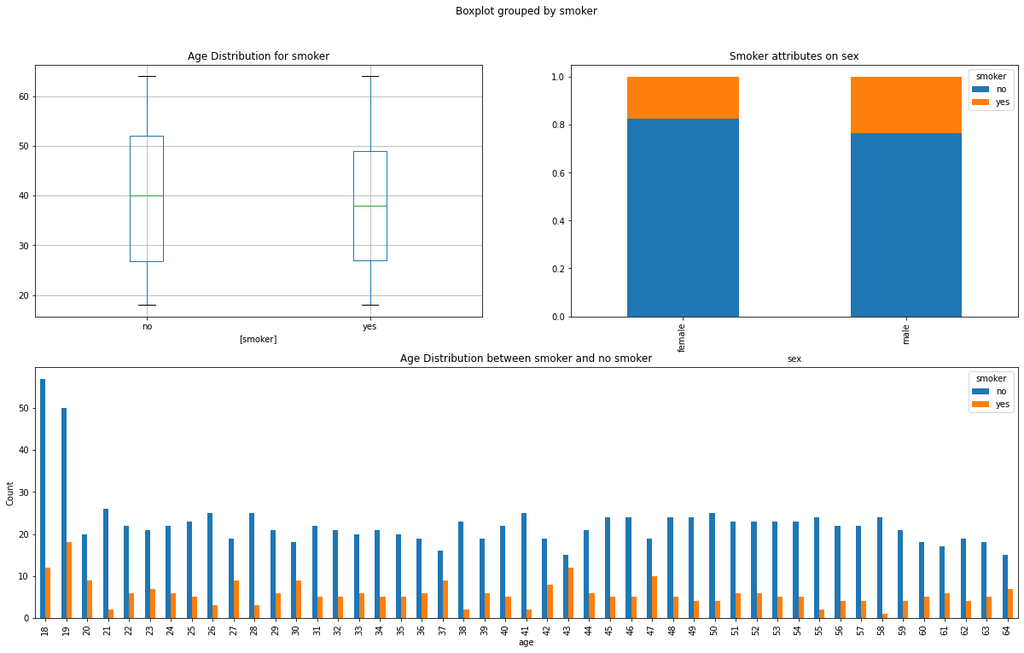

```python
smoker_sex = pd.crosstab(df.sex, df.smoker, normalize = 'index')
smoker_age = pd.crosstab(df.age, df.smoker)

fig, (ax1, ax2) = plt.subplots(2, 1, figsize=(20,12))

ax1 = plt.subplot(212)
smoker_age.plot(kind = 'bar', ax=ax1)
ax1.set_ylabel('Count')
ax1.set_title('Age Distribution between smoker and no smoker')

ax2 = plt.subplot(222)
ax2.margins()
smoker_sex.plot(kind='bar', stacked=True, ax=ax2)
ax2.set_title('Smoker attributes on sex')

ax3 = plt.subplot(221)
ax3.margins()
df.boxplot(by=['smoker'], column='age', ax = ax3)
ax3.set_title('Age Distribution for smoker')
plt.show()
```

In this plots we see that the population is almost no smoker both for male and female, but we have more males than females that are smoker. The age of smoker is lower than for no smoker. The distribution of smoker on the age has an irregular pattern.

From this first part of the analysis we have no strong difference in the age and sex distribution.

#### Age and charges

Now we analyze the relationship between age and charges dividing the population on sex.

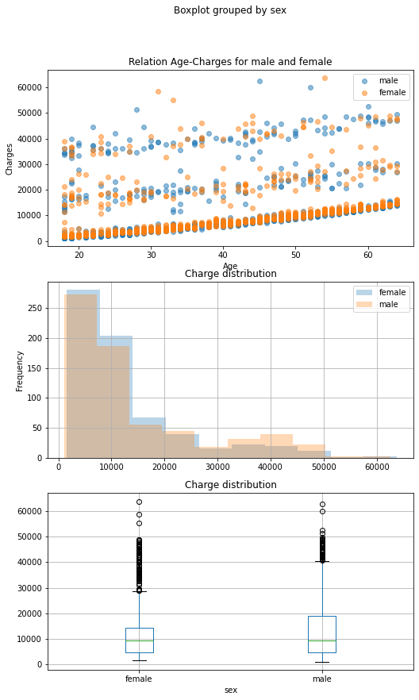

```python
fig, ax=plt.subplots(3,1, figsize = (8, 14))

ax[0].scatter(df[male]['age'], df[male]['charges'], label = 'male', alpha = 0.5)
ax[0].scatter(df[~male]['age'], df[~male]['charges'], label = 'female', alpha = 0.5)
ax[0].set_title('Relation Age-Charges for male and female')
ax[0].set_xlabel('Age')
ax[0].set_ylabel('Charges')
ax[0].legend()

#ax[1].hist(df[male]['charges'], alpha= 0.3 ,label = 'male')
#ax[1].hist(df[~male]['charges'], alpha= 0.3 ,label = 'female')
df.groupby('sex').charges.plot(kind='hist', ax = ax[1], alpha = 0.3)
ax[1].set_title('Charge distribution')

ax[1].grid()
ax[1].legend()


df.boxplot(column='charges', by = 'sex', ax = ax[2])
#ax[2].set_xticklabels(['male','female'])
ax[2].set_title('Charge distribution')

plt.show()
```

In the first plot we see the relationship between age and charges and we see the first interessant thing. There is a positive relationship between the age and charges, both for male and female. We can see 3 different groups on the charges but this grouping don´t depend on the sex, as we can see from the plot in the middle. There we can see only that we have more male than famale paying more than 30.000 USD.

Now we analyze the attribute smoker to see if exist correlation with other variables.

### Feature: Smoker

#### Smoker and bmi

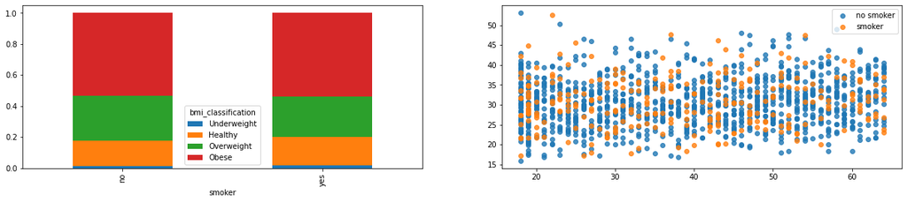

```python
smoker_bmi_class = pd.crosstab(df.smoker, df.bmi_classification, normalize='index')

f, a = plt.subplots(1,2, figsize= (21,4))

smoker_bmi_class.plot(y = ['Underweight','Healthy','Overweight','Obese'], kind='bar',stacked=True, ax = a[0])
a[1].scatter(df[~smoker].age, df[~smoker].bmi, label ='no smoker', alpha = 0.8)
a[1].scatter(df[smoker].age, df[smoker].bmi, label ='smoker', alpha = 0.8)
#df.groupby('smoker').plot(x = 'age', y = 'bmi' , kind='scatter')
a[1].legend(loc = 1)
plt.show()
```

From this plots we can´t see any clear relationship between smoker and bmi

#### Smoker and regions

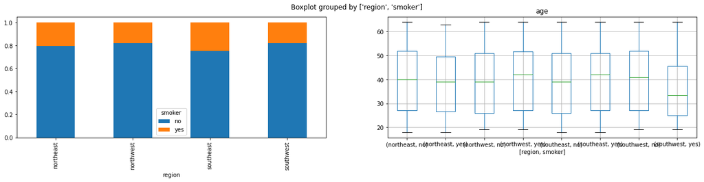

```python
f, a =plt.subplots(1,2,figsize=(21,4))

pd.crosstab(df.region, df.smoker, normalize='index').plot(kind='bar', stacked=True, ax=a[0])
df.boxplot(column = 'age', by = ['region','smoker'], ax=a[1])
```

#### Relationship between charges and year dividing the population by the smoker feature

Now we see if smoker has an impact on the relationship between years and charges.

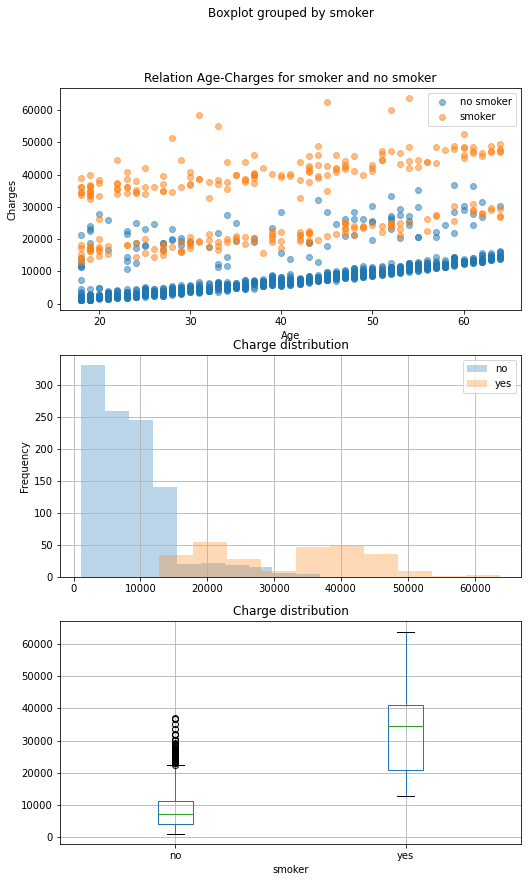

```python
fig, ax=plt.subplots(3,1, figsize = (8, 14))

ax[0].scatter(df[~smoker]['age'], df[~smoker]['charges'], label = 'no smoker', alpha = 0.5)
ax[0].scatter(df[smoker]['age'], df[smoker]['charges'], label = 'smoker', alpha = 0.5)

ax[0].set_xlabel('Age')
ax[0].set_ylabel('Charges')
ax[0].set_title('Relation Age-Charges for smoker and no smoker')
ax[0].legend()

df.groupby('smoker').charges.plot(kind='hist', ax=ax[1], alpha = 0.3)
ax[1].grid()
ax[1].legend()
ax[1].set_title('Charge distribution')

df.boxplot(column = 'charges', by='smoker', ax = ax[2])
ax[2].set_title('Charge distribution')

plt.show()
```

As we can see from the first plot, the smoke attribute divides the relationship between charge and age into 2 groups, no smoker downstair and smokerupstair . The no smoker pay lass than the smoker.

We can see from the plt in the middle that we have 3 different charge distribution:

- one for no smoker group
- two for smoker group

### Feature : Bmi

#### Sex and bmi

[figure not shown]

```python
bmi_sex = pd.crosstab(df.sex, df.bmi_classification,normalize='index')
sex_bmi = pd.crosstab(df.bmi_classification, df.sex, normalize='index')

fig, ax = plt.subplots(2,2, figsize = (21,10))

bmi_sex.plot.bar(y=['Underweight','Healthy','Overweight','Obese'], stacked=True, ax = ax[0,0])
ax[0,0].set_title('Population for bmi class')

sex_bmi.plot.bar(stacked=True, ax = ax[0,1])
ax[0,1].set_title('XXXX')

df[male].boxplot(column = 'charges', by = 'bmi_classification', ax = ax[1,0])
ax[1,0].set_xticklabels(['Obese', 'Overweight', 'Healthy', 'Underweight'])
ax[1,0].set_title('Charge distribution for male')

df[~male].boxplot(column = 'charges', by = 'bmi_classification', ax = ax[1,1])
ax[1,1].set_xticklabels(['Obese', 'Overweight', 'Healthy', 'Underweight'])
ax[1,1].set_title('Charge distribution for female')

plt.margins()
plt.show()
```

From this plots we can see that male and female are equally distribuited on the bmi classification. From the boxplots we don´t find any relationship between charges distribution on bmi classification for male and female. We can conclude that the sex attributes has no particular correlation with charges.

Now we make the same analysys on the group smoker and no smoker

#### Bmi and smoker

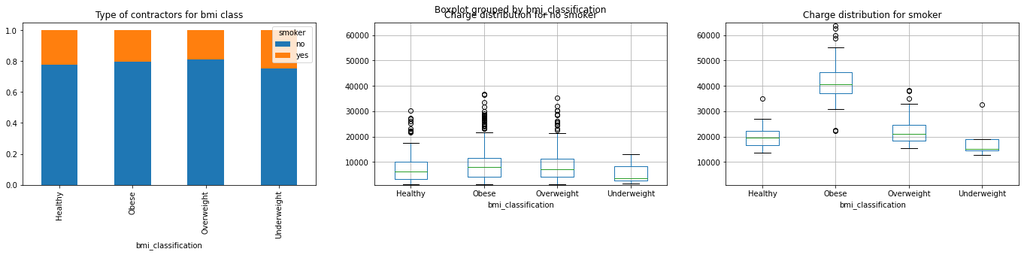

```python
tab = pd.crosstab(df.bmi_classification,df.smoker,normalize = 'index')

fig, ax = plt.subplots(1,3, figsize = (23,4))

tab.plot.bar(stacked = True, ax = ax[0])
ax[0].set_title('Type of contractors for bmi class')

df[~smoker].boxplot(column = 'charges', by='bmi_classification', ax = ax[1])
ax[1].set_title('Charge distribution for no smoker')
ax[1].set(ylim=(1000 ,65000))

df[smoker].boxplot(column = 'charges', by='bmi_classification', ax = ax[2])
ax[2].set_title('Charge distribution for smoker')
ax[2].set(ylim=(1000 ,65000))

plt.show()
```

From this plots we see clearly that for the no smoker group there is no different charges based on the bmi classification. Contrarily we can see for the smoker group that we have a correlation with the bmi classification and that the combination smoker plu obese cause the hiher charges.

Important to see is the difference in cost distribution between smokers and non-smokers in the Obese group

#### Relation between bmi and charges dividing the population by the smoker feature

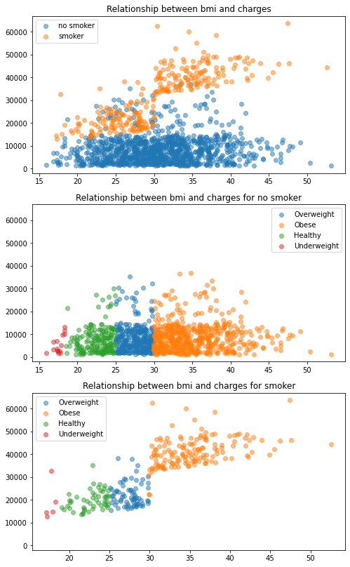

```python
fig, ax=plt.subplots(3,1, sharey = True, figsize = (8,14))

ax[0].scatter(x=df[~smoker].bmi, y=df[~smoker].charges, label='no smoker', alpha = 0.5)
ax[0].scatter(x=df[smoker].bmi, y=df[smoker].charges, label='smoker', alpha = 0.5)

ax[0].legend()
ax[0].set_title('Relationship between bmi and charges')

for i in df['bmi_classification'].unique():
    t1 = df[~smoker][df['bmi_classification'] == i]
    t2 = df[smoker][df['bmi_classification'] == i]
    ax[1].scatter(t1.bmi, t1.charges, label = i, alpha = 0.5)
    ax[2].scatter(t2.bmi, t2.charges, label = i, alpha = 0.5)
    ax[1].set_title('Relationship between bmi and charges for no smoker')
    ax[2].set_title('Relationship between bmi and charges for smoker')
    ax[1].legend()
    ax[2].legend()
plt.show()
```

In this plots we show the ralation between bmi and charges for two different groups, no smoker and smoker. Is clear that for no smoker we have no relation with the bmi contrary as for the smoker group. For the smoker group we see that for a bmi >= 30 we have a different charge distribution.

## Hipothesis testing

In this part we will make 3 different hypothesis on the data and we will test it with statistical considerations

### Hypothesis 1

- H0 = charges are normal distributed
- H1 = charges are not normal distributed

```python
from scipy.stats import normaltest

normaltest(df.charges, axis=0, nan_policy='propagate')
```

```
NormaltestResult(statistic=336.8851220567733, pvalue=7.019807901276197e-74)
```

We have a pvalue < 0.5 and for this reason we have to reject the null hipothesys and say that this values are not normally distribuited. We can see here the skew and the kurtosis values.

```python
df.charges.skew() , df.charges.kurt()
```

```
(1.5158796580240388, 1.6062986532967907)
```

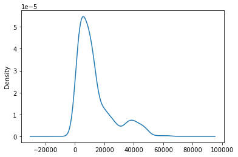

```python
df.charges.plot(kind='density')
plt.show()
```

### Hypothesis 2

- H0 = charges for smoker and no smoker has the same distribution
- H1 = charges for smoker and no smoker has different distribution

```python
from scipy.stats import mannwhitneyu

mannwhitneyu_result = mannwhitneyu(df[smoker].charges, df[~smoker].charges)
print(mannwhitneyu_result)
```

```
MannwhitneyuResult(statistic=7403.0, pvalue=2.6351167222517853e-130)
```

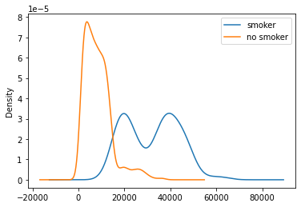

```python
df[smoker].charges.plot(kind='density', label = 'smoker')
df[~smoker].charges.plot(kind='density', label = 'no smoker')
plt.legend()
plt.show()
```

- H0 = Smoker with bmi>29.9 has the same distribution than smoker with bmi<=29.9
- H1 = Smoker with bmi>29.9 has different distribution than smoker with bmi<=29.9

```python
from scipy.stats import mannwhitneyu

p1 = df[(df.smoker=='yes')& (df.bmi<=29.9)].charges
p2 = df[(df.smoker=='yes')& (df.bmi>29.9)].charges

mannwhitneyu(p1,p2)
```

```
MannwhitneyuResult(statistic=214.0, pvalue=1.7333616855343086e-44)
```

```
MannwhitneyuResult(statistic=214.0, pvalue=1.7333616855343086e-44)
```

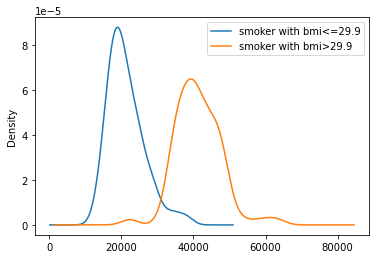

```python
p1 = df[(df.smoker=='yes')& (df.bmi<=29.9)].charges
p2 = df[(df.smoker=='yes')& (df.bmi>29.9)].charges

mannwhitneyu_result = mannwhitneyu(p1.values,p2.values)
print(mannwhitneyu_result)

p1.plot(kind='density', label = 'smoker with bmi<=29.9')
p2.plot(kind='density', label = 'smoker with bmi>29.9')
plt.legend()
plt.show()
```